# EXPLORATORY DATA ANALYSIS

## Exploratory data analysis (EDA) is a crucial component of data science which allows you to develop the gist of what your data look like and what kinds of questions might be answered by them. For this task we are going to clean, sanitize and explore our data.

```python
# Importing the required packages here

import numpy as np
import pandas as pd
import seaborn as sns
import ast, json

from datetime import datetime

import matplotlib.pyplot as plt




import missingno
```

```python
#### load the movie and credit and create their dataframes

credits_df = pd.read_csv('Credit.txt')
movies_df = pd.read_csv('Movies.csv')
```

### Data Cleansing

#### Clean the data and see which are the redundant or unnecessary columns

It is always easier to make your decisions from the data which is actually relevant and concise. Remove the following columns ['keywords', 'homepage', 'status', 'tagline', 'original_language', 'homepage', 'overview', 'production_companies', 'original_title', 'title_y'] from the data set as they will not be used in the analysis.

```python
movies_df.head(2)
```

|  | budget | genres | homepage | id | keywords | original_language | original_title | overview | popularity | production_companies | production_countries | release_date | revenue | runtime | spoken_languages | status | tagline | title | vote_average | vote_count |
| --- | --- | --- | --- | --- | --- | --- | --- | --- | --- | --- | --- | --- | --- | --- | --- | --- | --- | --- | --- | --- |
| 0 | 237000000 | [{"id": 28, "name": "Action"}, {"id": 12, "nam... | http://www.avatarmovie.com/ | 19995 | [{"id": 1463, "name": "culture clash"}, {"id":... | en | Avatar | In the 22nd century, a paraplegic Marine is di... | 150.437577 | [{"name": "Ingenious Film Partners", "id": 289... | [{"iso_3166_1": "US", "name": "United States o... | 2009-12-10 | 2787965087 | 162.0 | [{"iso_639_1": "en", "name": "English"}, {"iso... | Released | Enter the World of Pandora. | Avatar | 7.2 | 11800 |
| 1 | 300000000 | [{"id": 12, "name": "Adventure"}, {"id": 14, "... | http://disney.go.com/disneypictures/pirates/ | 285 | [{"id": 270, "name": "ocean"}, {"id": 726, "na... | en | Pirates of the Caribbean: At World's End | Captain Barbossa, long believed to be dead, ha... | 139.082615 | [{"name": "Walt Disney Pictures", "id": 2}, {"... | [{"iso_3166_1": "US", "name": "United States o... | 2007-05-19 | 961000000 | 169.0 | [{"iso_639_1": "en", "name": "English"}] | Released | At the end of the world, the adventure begins. | Pirates of the Caribbean: At World's End | 6.9 | 4500 |

```python
movies_df.columns
```

```
Index(['budget', 'genres', 'homepage', 'id', 'keywords', 'original_language',
       'original_title', 'overview', 'popularity', 'production_companies',
       'production_countries', 'release_date', 'revenue', 'runtime',
       'spoken_languages', 'status', 'tagline', 'title', 'vote_average',
       'vote_count'],
      dtype='object')
```

```python
#over here we use the drop method to delete the columns that we won't  need.
movies_df.drop( ['keywords', 'homepage', 'status', 'tagline', 'original_language', 'homepage', 'overview', 'production_companies', 'original_title'], axis=1, inplace=True)
```

```python
movies_df.columns
```

```
Index(['budget', 'genres', 'id', 'popularity', 'production_countries',
       'release_date', 'revenue', 'runtime', 'spoken_languages', 'title',
       'vote_average', 'vote_count'],
      dtype='object')
```

```python
movies_df.dtypes
```

```
budget                    int64
genres                   object
id                        int64
popularity              float64
production_countries     object
release_date             object
revenue                   int64
runtime                 float64
spoken_languages         object
title                    object
vote_average            float64
vote_count                int64
dtype: object
```

#### Removing the duplicacy in the rows (if any)

```python
movies_df.duplicated().sum() #looks like we don't realy have duplicated rows
```

```
0
```

#### Some movies in the database have zero budget or zero revenue which implies that their values have not been recorded or some information is missing. discard such entries from the dataframe

```python
# Code here
#here we have two option we..can can convert the 0 values to np.nan or use the loc method

#below we use the loc method to reset the df. without the budget and revenue where values == 0
movies_df = movies_df.loc[(movies_df['budget']!=0) & (movies_df['revenue'] != 0) ]
```

#### To manipulate the columns easily, it is important that we make use of the python objects. Changing release date column into Date format and extracting the year from the date which will help us in analysing yearly data.

```python
# Change the release_date column to DateTime column
movies_df['release_date'] = pd.to_datetime(movies_df.release_date)

# Extract the release year from every release date
movies_df['release_year'] = movies_df.release_date.dt.year
```

#### Change budget and revenue columns format to integer using numpy’s int64 method.

```python
# code here
movies_df['revenue'] = movies_df.revenue.astype(np.int64)
movies_df[['revenue', 'budget']].dtypes
```

```
revenue    int64
budget     int64
dtype: object
```

On checking the dataset, we see that genres, keywords, production_companies, production_countries, spoken_languages are in the JSON format which will make it difficult while manipulating the dataframe. Now let’s flatten these columns into a format that can be easily interpreted.

I will help you convert them into strings and later convert them into lists. Writing a generic function to parse JSON columns.

```python
movies_df.head()
```

[output not shown]

```python
#thanks for your help :) if i had to do it by myself i don't know the aproach i would have had take.
#at least now I understand the how the apply method works


def parse_col_json(column, key):
    """
    Args:
        column: string
            name of the column to be processed.
        key: string
            name of the dictionary key which needs to be extracted
    """
    for index,i in zip(movies_df.index,movies_df[column].apply(json.loads)):
        list1=[]
        for j in range(len(i)):
            list1.append((i[j][key]))# the key 'name' contains the name of the genre
        movies_df.loc[index,column]=str(list1)

parse_col_json('genres', 'name')
parse_col_json('spoken_languages', 'name')
parse_col_json('production_countries', 'name')
```

### Now onto the exploration

#### Identifying relationships between variables / features

The main goal here is to identify and create relationships which can help you to build ideas.I have define questions which can help you build some relationships to look at.

#### Which are the 5 most expensive movies? Comparison between the extremes? Exploring the most expensive movies, it can tell you if they were even worth the money spent on them based on their performance and revenue generated.

```python
movies_df.columns
```

[output not shown]

```python
# Code here

#to get the top 5 expensive movies we just need to sort the values by descendingly based on their budget
movies_df.sort_values('budget',ascending=False)[['title', 'budget']].head()
```

|  | title | budget |
| --- | --- | --- |
| 17 | Pirates of the Caribbean: On Stranger Tides | 380000000 |
| 1 | Pirates of the Caribbean: At World's End | 300000000 |
| 7 | Avengers: Age of Ultron | 280000000 |
| 10 | Superman Returns | 270000000 |
| 4 | John Carter | 260000000 |

```python
# code here

movies_df['profit'] = (movies_df.revenue + movies_df.budget)
top_5_profit = movies_df[['title', 'profit']].sort_values('profit', ascending=False).head()
top_5_profit
```

|  | title | profit |
| --- | --- | --- |
| 0 | Avatar | 3024965087 |
| 25 | Titanic | 2045034188 |
| 16 | The Avengers | 1739557910 |
| 44 | Furious 7 | 1696249360 |
| 7 | Avengers: Age of Ultron | 1685403694 |

#### find the most talked about movies, sort the dataframe on the popularity column

```python
movies_df.sort_values('popularity', ascending=False)[['title', 'popularity']].head()
```

|  | title | popularity |
| --- | --- | --- |
| 546 | Minions | 875.581305 |
| 95 | Interstellar | 724.247784 |
| 788 | Deadpool | 514.569956 |
| 94 | Guardians of the Galaxy | 481.098624 |
| 127 | Mad Max: Fury Road | 434.278564 |

#### Find Movies which are rated above 7

```python
# Code here

movies_df.sort_values('popularity', ascending=False).loc[movies_df['vote_average'] > 7, :]
```

|  | budget | genres | id | popularity | production_countries | release_date | revenue | runtime | spoken_languages | title | vote_average | vote_count | release_year | profit |
| --- | --- | --- | --- | --- | --- | --- | --- | --- | --- | --- | --- | --- | --- | --- |
| 95 | 165000000 | ['Adventure', 'Drama', 'Science Fiction'] | 157336 | 724.247784 | ['Canada', 'United States of America', 'United... | 2014-11-05 | 675120017 | 169.0 | ['English'] | Interstellar | 8.1 | 10867 | 2014 | 840120017 |
| 788 | 58000000 | ['Action', 'Adventure', 'Comedy'] | 293660 | 514.569956 | ['United States of America'] | 2016-02-09 | 783112979 | 108.0 | ['English'] | Deadpool | 7.4 | 10995 | 2016 | 841112979 |
| 94 | 170000000 | ['Action', 'Science Fiction', 'Adventure'] | 118340 | 481.098624 | ['United Kingdom', 'United States of America'] | 2014-07-30 | 773328629 | 121.0 | ['English'] | Guardians of the Galaxy | 7.9 | 9742 | 2014 | 943328629 |
| 127 | 150000000 | ['Action', 'Adventure', 'Science Fiction', 'Th... | 76341 | 434.278564 | ['Australia', 'United States of America'] | 2015-05-13 | 378858340 | 120.0 | ['English'] | Mad Max: Fury Road | 7.2 | 9427 | 2015 | 528858340 |
| 199 | 140000000 | ['Adventure', 'Fantasy', 'Action'] | 22 | 271.972889 | ['United States of America'] | 2003-07-09 | 655011224 | 143.0 | ['English'] | Pirates of the Caribbean: The Curse of the Bla... | 7.5 | 6985 | 2003 | 795011224 |
| 82 | 170000000 | ['Science Fiction', 'Action', 'Drama', 'Thrill... | 119450 | 243.791743 | ['United States of America'] | 2014-06-26 | 710644566 | 130.0 | ['English'] | Dawn of the Planet of the Apes | 7.3 | 4410 | 2014 | 880644566 |
| 88 | 165000000 | ['Adventure', 'Family', 'Animation', 'Action',... | 177572 | 203.734590 | ['United States of America'] | 2014-10-24 | 652105443 | 102.0 | ['English'] | Big Hero 6 | 7.8 | 6135 | 2014 | 817105443 |
| 26 | 250000000 | ['Adventure', 'Action', 'Science Fiction'] | 271110 | 198.372395 | ['United States of America'] | 2016-04-27 | 1153304495 | 147.0 | ['Română', 'English', 'Deutsch', 'Pусский'] | Captain America: Civil War | 7.1 | 7241 | 2016 | 1403304495 |
| 3865 | 3300000 | ['Drama'] | 244786 | 192.528841 | ['United States of America'] | 2014-10-10 | 13092000 | 105.0 | ['English'] | Whiplash | 8.3 | 4254 | 2014 | 16392000 |
| 65 | 185000000 | ['Drama', 'Action', 'Crime', 'Thriller'] | 155 | 187.322927 | ['United Kingdom', 'United States of America'] | 2008-07-16 | 1004558444 | 152.0 | ['English', '普通话'] | The Dark Knight | 8.2 | 12002 | 2008 | 1189558444 |
| 270 | 108000000 | ['Drama', 'Adventure', 'Science Fiction'] | 286217 | 167.932870 | ['United States of America'] | 2015-09-30 | 630161890 | 141.0 | ['English', '普通话'] | The Martian | 7.6 | 7268 | 2015 | 738161890 |
| 96 | 160000000 | ['Action', 'Thriller', 'Science Fiction', 'Mys... | 27205 | 167.583710 | ['United Kingdom', 'United States of America'] | 2010-07-14 | 825532764 | 148.0 | ['English', '日本語', 'Français'] | Inception | 8.1 | 13752 | 2010 | 985532764 |
| 124 | 150000000 | ['Animation', 'Adventure', 'Family'] | 109445 | 165.125366 | ['United States of America'] | 2013-11-27 | 1274219009 | 102.0 | ['English'] | Frozen | 7.3 | 5295 | 2013 | 1424219009 |
| 0 | 237000000 | ['Action', 'Adventure', 'Fantasy', 'Science Fi... | 19995 | 150.437577 | ['United States of America', 'United Kingdom'] | 2009-12-10 | 2787965087 | 162.0 | ['English', 'Español'] | Avatar | 7.2 | 11800 | 2009 | 3024965087 |
| 662 | 63000000 | ['Drama'] | 550 | 146.757391 | ['Germany', 'United States of America'] | 1999-10-15 | 100853753 | 139.0 | ['English'] | Fight Club | 8.3 | 9413 | 1999 | 163853753 |
| 2522 | 14000000 | ['History', 'Drama', 'Thriller', 'War'] | 205596 | 145.364591 | ['United Kingdom'] | 2014-11-14 | 233555708 | 113.0 | ['English'] | The Imitation Game | 8.0 | 5723 | 2014 | 247555708 |
| 16 | 220000000 | ['Science Fiction', 'Action', 'Adventure'] | 24428 | 144.448633 | ['United States of America'] | 2012-04-25 | 1519557910 | 143.0 | ['English'] | The Avengers | 7.4 | 11776 | 2012 | 1739557910 |
| 3337 | 6000000 | ['Drama', 'Crime'] | 238 | 143.659698 | ['United States of America'] | 1972-03-14 | 245066411 | 175.0 | ['English', 'Italiano', 'Latin'] | The Godfather | 8.4 | 5893 | 1972 | 251066411 |
| 693 | 61000000 | ['Mystery', 'Thriller', 'Drama'] | 210577 | 143.041543 | ['United States of America'] | 2014-10-01 | 369330363 | 145.0 | ['English'] | Gone Girl | 7.9 | 5862 | 2014 | 430330363 |
| 456 | 68000000 | ['War', 'Drama', 'Action'] | 228150 | 139.575085 | ['United Kingdom', 'United States of America',... | 2014-10-15 | 211817906 | 135.0 | ['English'] | Fury | 7.4 | 3946 | 2014 | 279817906 |
| 809 | 55000000 | ['Comedy', 'Drama', 'Romance'] | 13 | 138.133331 | ['United States of America'] | 1994-07-06 | 677945399 | 142.0 | ['English'] | Forrest Gump | 8.2 | 7927 | 1994 | 732945399 |
| 262 | 93000000 | ['Adventure', 'Fantasy', 'Action'] | 120 | 138.049577 | ['New Zealand', 'United States of America'] | 2001-12-18 | 871368364 | 178.0 | ['English'] | The Lord of the Rings: The Fellowship of the Ring | 8.0 | 8705 | 2001 | 964368364 |
| 1881 | 25000000 | ['Drama', 'Crime'] | 278 | 136.747729 | ['United States of America'] | 1994-09-23 | 28341469 | 142.0 | ['English'] | The Shawshank Redemption | 8.5 | 8205 | 1994 | 53341469 |
| 7 | 280000000 | ['Action', 'Adventure', 'Science Fiction'] | 99861 | 134.279229 | ['United States of America'] | 2015-04-22 | 1405403694 | 141.0 | ['English'] | Avengers: Age of Ultron | 7.3 | 6767 | 2015 | 1685403694 |
| 276 | 100000000 | ['Adventure', 'Fantasy', 'Family'] | 672 | 132.397737 | ['Germany', 'United Kingdom', 'United States o... | 2002-11-13 | 876688482 | 161.0 | ['English'] | Harry Potter and the Chamber of Secrets | 7.4 | 5815 | 2002 | 976688482 |
| 77 | 175000000 | ['Drama', 'Comedy', 'Animation', 'Family'] | 150540 | 128.655964 | ['United States of America'] | 2015-06-09 | 857611174 | 94.0 | ['English'] | Inside Out | 8.0 | 6560 | 2015 | 1032611174 |
| 3719 | 3000000 | ['Drama'] | 510 | 127.525581 | ['United States of America'] | 1975-11-18 | 108981275 | 133.0 | ['English'] | One Flew Over the Cuckoo's Nest | 8.2 | 2919 | 1975 | 111981275 |
| 2912 | 11000000 | ['Adventure', 'Action', 'Science Fiction'] | 11 | 126.393695 | ['United States of America'] | 1977-05-25 | 775398007 | 121.0 | ['English'] | Star Wars | 8.1 | 6624 | 1977 | 786398007 |
| 329 | 94000000 | ['Adventure', 'Fantasy', 'Action'] | 122 | 123.630332 | ['New Zealand', 'United States of America'] | 2003-12-01 | 1118888979 | 201.0 | ['English'] | The Lord of the Rings: The Return of the King | 8.1 | 8064 | 2003 | 1212888979 |
| 3232 | 8000000 | ['Thriller', 'Crime'] | 680 | 121.463076 | ['United States of America'] | 1994-10-08 | 213928762 | 154.0 | ['English', 'Español', 'Français'] | Pulp Fiction | 8.3 | 8428 | 1994 | 221928762 |
| ... | ... | ... | ... | ... | ... | ... | ... | ... | ... | ... | ... | ... | ... | ... |
| 4200 | 1644736 | ['Comedy', 'Romance'] | 34106 | 3.426314 | ['United States of America'] | 1938-08-23 | 7433101 | 126.0 | ['English', 'Pусский'] | You Can't Take It With You | 7.2 | 79 | 1938 | 9077837 |
| 3828 | 3500000 | ['Drama', 'Action', 'Crime'] | 9516 | 3.418871 | ['United States of America'] | 1993-05-26 | 27900000 | 97.0 | ['English'] | Menace II Society | 7.2 | 173 | 1993 | 31400000 |
| 4497 | 600000 | ['History', 'Documentary', 'Music'] | 9459 | 3.409764 | ['United States of America'] | 1970-03-26 | 34505110 | 225.0 | ['English'] | Woodstock | 7.1 | 66 | 1970 | 35105110 |
| 3975 | 2900000 | ['Comedy', 'Drama'] | 248 | 3.370225 | ['United States of America'] | 1961-12-18 | 5000000 | 136.0 | ['English', 'Español'] | Pocketful of Miracles | 7.3 | 25 | 1961 | 7900000 |
| 3228 | 7700000 | ['Romance'] | 185008 | 3.353176 | ['India'] | 2013-05-31 | 46000000 | 159.0 | ['हिन्दी'] | Yeh Jawaani Hai Deewani | 7.2 | 79 | 2013 | 53700000 |
| 4713 | 160000 | ['Documentary', 'History'] | 1779 | 3.284903 | ['United States of America'] | 1989-09-01 | 6706368 | 91.0 | ['English'] | Roger & Me | 7.4 | 90 | 1989 | 6866368 |
| 3832 | 3500000 | ['Drama'] | 27029 | 3.281509 | ['United States of America'] | 1959-06-18 | 12800000 | 149.0 | ['English'] | The Nun's Story | 7.4 | 46 | 1959 | 16300000 |
| 4592 | 385907 | ['Drama'] | 3059 | 3.232447 | ['United States of America'] | 1916-09-04 | 8394751 | 197.0 | ['English'] | Intolerance | 7.4 | 60 | 1916 | 8780658 |
| 2947 | 10000000 | ['Drama', 'History'] | 30973 | 3.208172 | ['Canada', 'United Kingdom'] | 2003-09-11 | 4069090 | 125.0 | ['English'] | The Visual Bible: The Gospel of John | 8.2 | 12 | 2003 | 14069090 |
| 101 | 160000000 | ['Action', 'Science Fiction', 'Adventure'] | 49538 | 3.195174 | ['United States of America'] | 2011-05-24 | 353624124 | 132.0 | ['Deutsch', 'English', 'Español', 'Français', ... | X-Men: First Class | 7.1 | 5181 | 2011 | 513624124 |
| 314 | 10000000 | ['Crime', 'Drama', 'Mystery', 'Thriller'] | 29193 | 3.091077 | ['United States of America'] | 1997-09-08 | 13835130 | 110.0 | ['English'] | The Spanish Prisoner | 7.1 | 73 | 1997 | 23835130 |
| 2801 | 12500000 | ['Crime', 'Drama'] | 21612 | 2.950618 | ['United States of America'] | 1996-01-26 | 1227324 | 99.0 | ['Italiano', 'English'] | The Funeral | 7.3 | 31 | 1996 | 13727324 |
| 4521 | 2053648 | ['Documentary'] | 14271 | 2.778633 | ['United States of America'] | 1999-10-22 | 500000 | 102.0 | ['English'] | Beyond the Mat | 7.8 | 17 | 1999 | 2553648 |
| 3432 | 6500000 | ['Drama'] | 14631 | 2.639106 | ['United States of America'] | 2005-10-21 | 2025032 | 100.0 | ['English'] | The Work and the Glory II: American Zion | 8.0 | 6 | 2005 | 8525032 |
| 3722 | 4500000 | ['Thriller', 'Action', 'Drama', 'History'] | 375290 | 2.551559 | ['India'] | 2016-01-22 | 32000000 | 126.0 | ['العربية', 'हिन्दी', ''] | Airlift | 7.3 | 57 | 2016 | 36500000 |
| 4106 | 2000000 | ['Documentary'] | 12901 | 2.283796 | [] | 2007-07-27 | 1431623 | 102.0 | ['English'] | No End in Sight | 7.2 | 23 | 2007 | 3431623 |
| 2511 | 18000000 | ['Comedy', 'Family'] | 771 | 2.186927 | ['United States of America'] | 1990-11-09 | 476684675 | 103.0 | ['English'] | Home Alone | 7.1 | 2414 | 1990 | 494684675 |
| 2564 | 20000000 | ['Action', 'Comedy', 'Drama', 'Romance'] | 14736 | 2.027393 | ['United States of America'] | 2000-04-21 | 27728118 | 124.0 | ['English', 'Español'] | Love & Basketball | 7.4 | 88 | 2000 | 47728118 |
| 3816 | 3768785 | ['Action', 'Comedy', 'Music', 'Romance', 'West... | 25209 | 1.726175 | ['United States of America'] | 1950-05-17 | 8000000 | 107.0 | ['English'] | Annie Get Your Gun | 7.3 | 22 | 1950 | 11768785 |
| 4606 | 300000 | ['Music', 'Documentary'] | 21525 | 1.314576 | ['United States of America'] | 2003-01-23 | 7808524 | 112.0 | ['English'] | Tupac: Resurrection | 8.0 | 26 | 2003 | 8108524 |
| 4582 | 218 | ['Documentary', 'Drama'] | 1435 | 1.063439 | ['United States of America'] | 2003-10-19 | 1162014 | 91.0 | ['English'] | Tarnation | 7.5 | 22 | 2003 | 1162232 |
| 4696 | 8000 | ['Drama', 'Romance'] | 79120 | 1.041254 | ['United Kingdom'] | 2011-09-22 | 469947 | 96.0 | ['English'] | Weekend | 7.4 | 163 | 2011 | 477947 |
| 4002 | 2600000 | ['Documentary'] | 291 | 0.895946 | ['France', 'United States of America'] | 2004-07-09 | 3166000 | 105.0 | ['English'] | Riding Giants | 7.6 | 23 | 2004 | 5766000 |
| 4028 | 2500000 | ['Drama'] | 46849 | 0.301884 | ['United States of America'] | 2007-08-24 | 71904 | 100.0 | ['English'] | Eye of the Dolphin | 7.1 | 7 | 2007 | 2571904 |
| 4641 | 250 | ['Drama', 'Comedy', 'Animation'] | 51942 | 0.293649 | ['United States of America'] | 1998-08-28 | 203 | 72.0 | ['English'] | I Married a Strange Person! | 7.5 | 12 | 1998 | 453 |
| 4370 | 1000000 | ['Crime', 'Drama', 'Mystery', 'Thriller'] | 26791 | 0.280083 | ['United States of America'] | 2001-03-30 | 852206 | 119.0 | ['English'] | Brigham City | 7.3 | 4 | 2001 | 1852206 |
| 4792 | 20000 | ['Crime', 'Horror', 'Mystery', 'Thriller'] | 36095 | 0.212443 | ['Japan'] | 1997-11-06 | 99000 | 111.0 | ['日本語'] | Cure | 7.4 | 63 | 1997 | 119000 |
| 3875 | 2000000 | ['Romance', 'Drama'] | 108346 | 0.116150 | ['United Kingdom', 'United States of America'] | 1999-10-29 | 7 | 92.0 | ['English'] | Dreaming of Joseph Lees | 8.0 | 1 | 1999 | 2000007 |
| 3471 | 6000000 | ['Documentary'] | 57612 | 0.041651 | ['Bahamas', 'United Kingdom'] | 2008-02-15 | 7518876 | 42.0 | ['English'] | Dolphins and Whales: Tribes of the Ocean | 8.0 | 3 | 2008 | 13518876 |
| 2970 | 10500000 | ['Drama', 'Comedy'] | 88641 | 0.037073 | ['United States of America'] | 1994-09-02 | 123509 | 99.0 | ['English'] | There Goes My Baby | 8.5 | 2 | 1994 | 10623509 |

637 rows × 14 columns

#### Which year did we have the most profitable movies?

This will help raise some deeper questions about the years when movies didn’t do well or when they did. These are preliminary questions which give rise to questions providing deeper insights.

```python
# Code here

movies_df[['release_year','profit']].groupby('release_year').sum().sort_values('profit', ascending = False).head()
```

| release_year | profit |
| --- | --- |
| 2013 | 31100019222 |
| 2014 | 31064736072 |
| 2012 | 30883514859 |
| 2015 | 28871841945 |
| 2009 | 28062570702 |

#### Most successful genres — bar plot explaining the frequency of movies in each genre.

```python
 # Code here
```

to that I'm going to extract all the unique values then count how many time each genre appeared in the movies_df

```python
a = movies_df.genres  #make a copy of all the lists of genres
#over here we create a set that will alow us to have only unique values
b =set()


for i in a:
    b.update(i)  #we updata the set with all the lists in the variable a

all_genre = list(b) #then we convert the set to a list
all_genre
```

```
['Comedy',
 'Animation',
 'Drama',
 'Horror',
 'Science Fiction',
 'Crime',
 'Family',
 'Romance',
 'Foreign',
 'Music',
 'Thriller',
 'Adventure',
 'Western',
 'Action',
 'Fantasy',
 'Documentary',
 'Mystery',
 'History',
 'War']
```

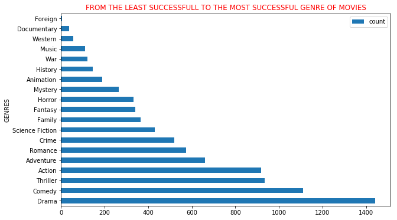

```python
a=movies_df.genres #just to inphasise that a is all the lists of genres

dict_of_genres = dict.fromkeys(all_genre, 0) #here we create a dict with genres as keys with 0 values

for i,e in dict_of_genres.items():  #so we get the keys as i and e as values
    for y in a:                     #and we get each list as y
        if i in y:                  #now we check if i(key) is in y(list)
            dict_of_genres[i]+=1    #if so, we add one to the value of that key




# then we create a dataset  of dict_of_genres
genre_count = pd.DataFrame.from_dict(dict_of_genres, orient='index', columns = ['count']).sort_values('count', ascending=False)

genre_count.plot(kind='barh',figsize=(10,6))
plt.title('FROM THE LEAST SUCCESSFULL TO THE MOST SUCCESSFUL GENRE OF MOVIES', color='r')
plt.ylabel('GENRES')
```

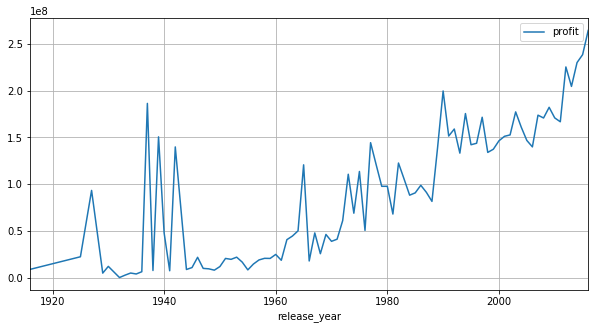

```python
#### Generate three different interesting visualizations with a data story.

# Code here


#with the plot below we can see how the industry evolves over the year


movies_df[['release_year','profit']].groupby('release_year').mean().plot(figsize=(10,5), grid=True)
```

let's give the runtime a little bit of attention. gfg if we describe the movies(mathematically) we notice that there's quiet a huge difference between the min and max. could that perhaps affect the profit or the likeness of the movies?

```python
movies_df.runtime.describe()
```

```
count    3229.000000
mean      110.724373
std        20.965694
min        41.000000
25%        96.000000
50%       107.000000
75%       121.000000
max       338.000000
Name: runtime, dtype: float64
```

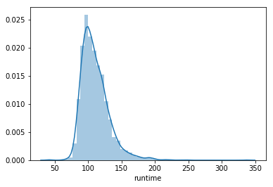

```python
sns.distplot(movies_df['runtime'] )
```

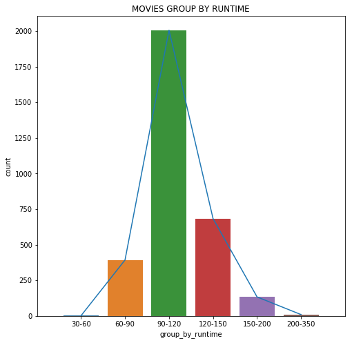

```python
#to be able to understand the relationship.
#we gonna create a categorical variable where we're going to store the movies group by time.

movies_df['group_by_runtime']  = pd.cut(movies_df.runtime, (30, 60, 90, 120, 150, 200, 350), labels=([
                                            '30-60','60-90', '90-120','120-150','150-200', '200-350'] ))

plt.figure(figsize=(8,8))
sns.countplot(x='group_by_runtime', data=movies_df,)
movies_df.groupby('group_by_runtime').popularity.count().plot()
plt.xlim(-1,6)
plt.title('MOVIES GROUP BY RUNTIME')

#the plot below shows that movies between 90-120 are famous followed by 120-150
```

### let's now see when it comes to profit how each group perform.

```python
movies_df.loc[movies_df.group_by_runtime == '150-200', 'title'].unique()
```

```
array(['Avatar', "Pirates of the Caribbean: At World's End",
       'The Dark Knight Rises', 'Harry Potter and the Half-Blood Prince',
       'Batman v Superman: Dawn of Justice', 'Superman Returns',
       "Pirates of the Caribbean: Dead Man's Chest",
       'The Hobbit: The Desolation of Smaug', 'King Kong', 'Titanic',
       'Transformers: Age of Extinction',
       'Transformers: Dark of the Moon', '2012', 'The Dark Knight',
       'Interstellar', 'The Hobbit: An Unexpected Journey',
       'The Curious Case of Benjamin Button', 'Pearl Harbor', 'Alexander',
       'Harry Potter and the Goblet of Fire', 'Troy', 'Armageddon',
       'The Last Samurai', 'Watchmen', 'The Revenant', 'Australia',
       "Harry Potter and the Philosopher's Stone", 'The Patriot',
       'The Aviator', 'The Lord of the Rings: The Fellowship of the Ring',
       'Ali', 'Gladiator', 'Harry Potter and the Chamber of Secrets',
       'American Gangster', 'Django Unchained', 'The Wolf of Wall Street',
       'Cloud Atlas', 'Gangs of New York',
       'The Lord of the Rings: The Two Towers', 'The Departed',
       'The Girl with the Dragon Tattoo', 'Meet Joe Black', 'Zodiac',
       'Cold Mountain', 'The Postman', 'Munich', 'Braveheart',
       'The Majestic', 'Inglourious Basterds', 'The Insider',
       'Saving Private Ryan', 'Les Misérables', 'Eyes Wide Shut',
       'Wyatt Earp', 'The Hateful Eight', 'The Green Mile',
       'Any Given Sunday', 'The Horse Whisperer', 'Lolita',
       'The Godfather: Part III', 'Grindhouse', 'Zero Dark Thirty',
       'The Thin Red Line', 'Casino', 'Prisoners', 'Nixon',
       'Miracle at St. Anna', 'The Firm', 'Ray', 'JFK', 'Amistad',
       'Baahubali: The Beginning', 'Magnolia', 'The English Patient',
       'Midnight in the Garden of Good and Evil', 'Reds',
       'Apocalypse Now', 'Out of Africa',
       'The Assassination of Jesse James by the Coward Robert Ford',
       'A Passage to India', 'The Right Stuff', 'A Bridge Too Far',
       "Schindler's List", 'Scarface', 'The Last Emperor',
       'There Will Be Blood', 'Little White Lies', 'Gandhi',
       'Paint Your Wagon', 'The Greatest Story Ever Told',
       'Dances with Wolves', 'The Fall of the Roman Empire', 'Amadeus',
       'My Fair Lady', '55 Days at Peking', 'Enter the Void',
       'The Color Purple', 'The Deer Hunter', 'Boogie Nights',
       'Metropolis', 'Downfall', 'The Godfather: Part II', 'Jackie Brown',
       'Patton', 'Doctor Zhivago', 'Barry Lyndon',
       'Kabhi Alvida Naa Kehna', 'The Longest Day', 'Oliver!',
       "It's a Mad, Mad, Mad, Mad World", 'Fiddler on the Roof',
       'Yeh Jawaani Hai Deewani', 'Quo Vadis', 'Pulp Fiction',
       'The Sound of Music', 'The Godfather',
       'The Last Temptation of Christ', 'Veer-Zaara', 'Hard to Be a God',
       'West Side Story', 'Rang De Basanti',
       'Once Upon a Time in the West', 'The Greatest Show on Earth',
       'The Great Escape', 'Boyhood', 'The Bridge on the River Kwai',
       'Judgment at Nuremberg', 'The Best Years of Our Lives',
       'Amores perros', 'The Good, the Bad and the Ugly', 'Fiza',
       'Hoop Dreams', 'Intolerance', 'The Big Parade'], dtype=object)
```

```
(-1, 6)
```

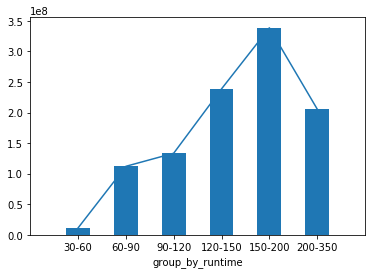

```python
movies_df.groupby('group_by_runtime').profit.mean().plot(kind='bar')
movies_df.groupby('group_by_runtime').profit.mean().plot()
plt.xlim(-1, 6)
```

## Now that you know how to Explore a Dataset and to ask questions and answer using code, Its time for you to do it from start to end. Please find in your task folder the Automobile Dataset.

### You are expected to give a write up of your visualizations, investigations and findings in the word document provided. The Code for the Analysis should be in a jupyter notebook named automobile.ipynb.

## Be creative :)